# Correlaciones entre variables del Censo y CASEN a nivel de Zona Censal

```r
tablamadre <- head(comuna_corr,50)
kbl(tablamadre) %>%
  kable_styling(bootstrap_options = c("striped", "hover")) %>%
  kable_paper() %>%
  scroll_box(width = "100%", height = "300px")
```

| unlist.c..x | Freq.x | anio.x | unlist.c..y | Freq.y | anio.y | unlist.c..x.1 | Freq.x.1 | anio.x.1 | unlist.c..y.1 | Freq.y.1 | anio.y.1 | unlist.c..x.2 | Freq.x.2 | anio.x.2 | unlist.c..y.2 | Freq.y.2 | anio.y.2 | unlist.c..x.3 | Freq.x.3 | anio.x.3 | unlist.c..y.3 | Freq.y.3 | anio.y.3 | unlist.c..x.4 | Freq.x.4 | anio.x.4 | unlist.c..y.4 | Freq.y.4 | anio.y.4 | … |
| --- | --- | --- | --- | --- | --- | --- | --- | --- | --- | --- | --- | --- | --- | --- | --- | --- | --- | --- | --- | --- | --- | --- | --- | --- | --- | --- | --- | --- | --- | --- |
| 1 | 38383 | 2017 | 2 | 22525 | 2017 | 3 | 20 | 2017 | 4 | 4489 | 2017 | 5 | 586 | 2017 | 6 | 55 | 2017 | 7 | 667 | 2017 | 8 | 261 | 2017 | 9 | 1 | 2017 | 10 | 1 | 2017 | … |
| 1 | 26410 | 2017 | 2 | 4142 | 2017 | 3 | 13 | 2017 | 4 | 446 | 2017 | 5 | 1766 | 2017 | 6 | 32 | 2017 | 7 | 353 | 2017 | 8 | 16 | 2017 | NA | NA | NA | 10 | 1 | 2017 | … |
| 1 | 7855 | 2017 | 2 | 4 | 2017 | 3 | 31 | 2017 | 4 | 248 | 2017 | 5 | 543 | 2017 | 6 | 10 | 2017 | 7 | 193 | 2017 | 8 | 42 | 2017 | 9 | 1 | 2017 | NA | NA | NA | … |
| 1 | 828 | 2017 | 2 | 10 | 2017 | 3 | 12 | 2017 | 4 | 13 | 2017 | 5 | 213 | 2017 | 6 | 1 | 2017 | 7 | 11 | 2017 | 8 | 4 | 2017 | NA | NA | NA | NA | NA | NA | … |
| 1 | 826 | 2017 | 2 | 2 | 2017 | 3 | 1141 | 2017 | 4 | 10 | 2017 | 5 | 32 | 2017 | 6 | 1 | 2017 | 7 | 13 | 2017 | 8 | 5 | 2017 | 9 | 1 | 2017 | NA | NA | NA | … |
| 1 | 2266 | 2017 | 2 | 4 | 2017 | 3 | 61 | 2017 | 4 | 50 | 2017 | 5 | 443 | 2017 | NA | NA | NA | 7 | 39 | 2017 | 8 | 8 | 2017 | NA | NA | NA | NA | NA | NA | … |
| 1 | 2424 | 2017 | 2 | 5 | 2017 | 3 | 11 | 2017 | 4 | 34 | 2017 | 5 | 169 | 2017 | 6 | 2 | 2017 | 7 | 58 | 2017 | 8 | 23 | 2017 | NA | NA | NA | NA | NA | NA | … |
| 1 | 80067 | 2017 | 2 | 27940 | 2017 | 3 | 31 | 2017 | 4 | 751 | 2017 | 5 | 2782 | 2017 | 6 | 44 | 2017 | 7 | 660 | 2017 | 8 | 176 | 2017 | 9 | 1 | 2017 | 10 | 1 | 2017 | … |
| 1 | 3236 | 2017 | 2 | 473 | 2017 | 3 | 1 | 2017 | 4 | 13 | 2017 | 5 | 198 | 2017 | 6 | 6 | 2017 | 7 | 49 | 2017 | 8 | 240 | 2017 | 9 | 1 | 2017 | NA | NA | NA | … |
| 1 | 466 | 2017 | NA | NA | NA | NA | NA | NA | 4 | 21 | 2017 | 5 | 36 | 2017 | 6 | 1 | 2017 | 7 | 3 | 2017 | 8 | 43 | 2017 | NA | NA | NA | NA | NA | NA | … |
| 1 | 4123 | 2017 | 2 | 3 | 2017 | 3 | 50 | 2017 | 4 | 20 | 2017 | 5 | 265 | 2017 | 6 | 28 | 2017 | 7 | 59 | 2017 | 8 | 45 | 2017 | 9 | 1 | 2017 | 10 | 1 | 2017 | … |
| 1 | 49994 | 2017 | 2 | 3683 | 2017 | 3 | 137 | 2017 | 4 | 1610 | 2017 | 5 | 705 | 2017 | 6 | 26 | 2017 | 7 | 808 | 2017 | 8 | 344 | 2017 | 9 | 1 | 2017 | 10 | 1 | 2017 | … |
| 1 | 173 | 2017 | NA | NA | NA | NA | NA | NA | 4 | 6 | 2017 | 5 | 234 | 2017 | 6 | 1 | 2017 | 7 | 13 | 2017 | 8 | 12 | 2017 | NA | NA | NA | NA | NA | NA | … |
| 1 | 3407 | 2017 | 2 | 5 | 2017 | 3 | 78 | 2017 | 4 | 229 | 2017 | 5 | 126 | 2017 | 6 | 6 | 2017 | 7 | 121 | 2017 | 8 | 172 | 2017 | 9 | 1 | 2017 | 10 | 1 | 2017 | … |
| 1 | 8580 | 2017 | 2 | 1110 | 2017 | 3 | 3 | 2017 | 4 | 48 | 2017 | 5 | 789 | 2017 | 6 | 12 | 2017 | 7 | 78 | 2017 | 8 | 50 | 2017 | 9 | 1 | 2017 | 10 | 1 | 2017 | … |
| 1 | 1798 | 2017 | 2 | 3 | 2017 | 3 | 1 | 2017 | 4 | 25 | 2017 | 5 | 7 | 2017 | 6 | 1 | 2017 | 7 | 30 | 2017 | 8 | 94 | 2017 | NA | NA | NA | NA | NA | NA | … |
| 1 | 46557 | 2017 | 2 | 6812 | 2017 | 3 | 9 | 2017 | 4 | 351 | 2017 | 5 | 1481 | 2017 | 6 | 38 | 2017 | 7 | 205 | 2017 | 8 | 112 | 2017 | NA | NA | NA | 10 | 1 | 2017 | … |
| 1 | 12730 | 2017 | 2 | 71 | 2017 | 3 | 16 | 2017 | 4 | 95 | 2017 | 5 | 2483 | 2017 | 6 | 68 | 2017 | 7 | 149 | 2017 | 8 | 39 | 2017 | NA | NA | NA | 10 | 1 | 2017 | … |
| 1 | 4360 | 2017 | 2 | 4 | 2017 | 3 | 4 | 2017 | 4 | 49 | 2017 | 5 | 263 | 2017 | 6 | 2 | 2017 | 7 | 23 | 2017 | 8 | 40 | 2017 | NA | NA | NA | 10 | 1 | 2017 | … |
| 1 | 5824 | 2017 | 2 | 74 | 2017 | NA | NA | NA | 4 | 10 | 2017 | 5 | 180 | 2017 | 6 | 6 | 2017 | 7 | 28 | 2017 | 8 | 31 | 2017 | NA | NA | NA | NA | NA | NA | … |
| 1 | 6192 | 2017 | 2 | 520 | 2017 | NA | NA | NA | 4 | 35 | 2017 | 5 | 30 | 2017 | 6 | 1 | 2017 | 7 | 34 | 2017 | 8 | 102 | 2017 | NA | NA | NA | NA | NA | NA | … |
| 1 | 18055 | 2017 | 2 | 514 | 2017 | 3 | 12 | 2017 | 4 | 84 | 2017 | 5 | 532 | 2017 | 6 | 20 | 2017 | 7 | 122 | 2017 | 8 | 63 | 2017 | 9 | 1 | 2017 | 10 | 1 | 2017 | … |
| 1 | 2535 | 2017 | 2 | 4 | 2017 | 3 | 22 | 2017 | 4 | 22 | 2017 | 5 | 271 | 2017 | 6 | 3 | 2017 | 7 | 46 | 2017 | 8 | 24 | 2017 | NA | NA | NA | NA | NA | NA | … |
| 1 | 3044 | 2017 | NA | NA | NA | 3 | 1 | 2017 | 4 | 19 | 2017 | 5 | 410 | 2017 | 6 | 3 | 2017 | 7 | 21 | 2017 | 8 | 13 | 2017 | NA | NA | NA | NA | NA | NA | … |
| 1 | 5411 | 2017 | 2 | 187 | 2017 | 3 | 6 | 2017 | 4 | 22 | 2017 | 5 | 530 | 2017 | 6 | 9 | 2017 | 7 | 36 | 2017 | 8 | 25 | 2017 | 9 | 1 | 2017 | 10 | 1 | 2017 | … |
| 1 | 68106 | 2017 | 2 | 17825 | 2017 | 3 | 8 | 2017 | 4 | 190 | 2017 | 5 | 707 | 2017 | 6 | 40 | 2017 | 7 | 391 | 2017 | 8 | 197 | 2017 | NA | NA | NA | 10 | 1 | 2017 | … |
| 1 | 77648 | 2017 | 2 | 10320 | 2017 | 3 | 12 | 2017 | 4 | 310 | 2017 | 5 | 640 | 2017 | 6 | 30 | 2017 | 7 | 379 | 2017 | 8 | 160 | 2017 | 9 | 1 | 2017 | 10 | 1 | 2017 | … |
| 1 | 4310 | 2017 | 2 | 24 | 2017 | 3 | 1 | 2017 | 4 | 25 | 2017 | 5 | 86 | 2017 | 6 | 2 | 2017 | 7 | 43 | 2017 | 8 | 15 | 2017 | NA | NA | NA | NA | NA | NA | … |
| 1 | 2430 | 2017 | NA | NA | NA | 3 | 1 | 2017 | 4 | 14 | 2017 | 5 | 162 | 2017 | 6 | 2 | 2017 | 7 | 34 | 2017 | 8 | 17 | 2017 | NA | NA | NA | NA | NA | NA | … |
| 1 | 2258 | 2017 | NA | NA | NA | 3 | 2 | 2017 | 4 | 16 | 2017 | 5 | 48 | 2017 | 6 | 5 | 2017 | 7 | 19 | 2017 | 8 | 25 | 2017 | NA | NA | NA | NA | NA | NA | … |
| 1 | 10347 | 2017 | 2 | 60 | 2017 | 3 | 7 | 2017 | 4 | 29 | 2017 | 5 | 237 | 2017 | 6 | 14 | 2017 | 7 | 39 | 2017 | 8 | 46 | 2017 | NA | NA | NA | NA | NA | NA | … |
| 1 | 11612 | 2017 | 2 | 212 | 2017 | 3 | 2 | 2017 | 4 | 53 | 2017 | 5 | 336 | 2017 | 6 | 13 | 2017 | 7 | 57 | 2017 | 8 | 35 | 2017 | NA | NA | NA | NA | NA | NA | … |
| 1 | 4848 | 2017 | NA | NA | NA | 3 | 5 | 2017 | 4 | 20 | 2017 | 5 | 356 | 2017 | 6 | 4 | 2017 | 7 | 37 | 2017 | 8 | 8 | 2017 | NA | NA | NA | NA | NA | NA | … |
| 1 | 12935 | 2017 | 2 | 10 | 2017 | 3 | 2 | 2017 | 4 | 25 | 2017 | 5 | 208 | 2017 | 6 | 4 | 2017 | 7 | 53 | 2017 | 8 | 51 | 2017 | NA | NA | NA | 10 | 1 | 2017 | … |
| 1 | 10069 | 2017 | 2 | 132 | 2017 | 3 | 1 | 2017 | 4 | 38 | 2017 | 5 | 297 | 2017 | 6 | 21 | 2017 | 7 | 54 | 2017 | 8 | 85 | 2017 | NA | NA | NA | 10 | 1 | 2017 | … |
| 1 | 38937 | 2017 | 2 | 1578 | 2017 | 3 | 7 | 2017 | 4 | 203 | 2017 | 5 | 1097 | 2017 | 6 | 25 | 2017 | 7 | 192 | 2017 | 8 | 56 | 2017 | 9 | 1 | 2017 | 10 | 1 | 2017 | … |
| 1 | 6597 | 2017 | 2 | 4 | 2017 | 3 | 7 | 2017 | 4 | 25 | 2017 | 5 | 308 | 2017 | 6 | 6 | 2017 | 7 | 33 | 2017 | 8 | 19 | 2017 | NA | NA | NA | NA | NA | NA | … |
| 1 | 12084 | 2017 | NA | NA | NA | 3 | 4 | 2017 | 4 | 80 | 2017 | 5 | 810 | 2017 | 6 | 6 | 2017 | 7 | 59 | 2017 | 8 | 31 | 2017 | NA | NA | NA | NA | NA | NA | … |
| 1 | 4521 | 2017 | 2 | 2 | 2017 | 3 | 3 | 2017 | 4 | 13 | 2017 | 5 | 233 | 2017 | 6 | 10 | 2017 | 7 | 24 | 2017 | 8 | 6 | 2017 | NA | NA | NA | 10 | 1 | 2017 | … |
| 1 | 2529 | 2017 | 2 | 1 | 2017 | 3 | 3 | 2017 | 4 | 13 | 2017 | 5 | 184 | 2017 | 6 | 6 | 2017 | 7 | 15 | 2017 | 8 | 13 | 2017 | NA | NA | NA | NA | NA | NA | … |
| 1 | 83616 | 2017 | 2 | 30690 | 2017 | 3 | 18 | 2017 | 4 | 716 | 2017 | 5 | 1257 | 2017 | 6 | 30 | 2017 | 7 | 508 | 2017 | 8 | 361 | 2017 | 9 | 1 | 2017 | 10 | 1 | 2017 | … |
| 1 | 10211 | 2017 | 2 | 1151 | 2017 | 3 | 2 | 2017 | 4 | 42 | 2017 | 5 | 106 | 2017 | 6 | 12 | 2017 | 7 | 64 | 2017 | 8 | 18 | 2017 | NA | NA | NA | 10 | 1 | 2017 | … |
| 1 | 11433 | 2017 | 2 | 8548 | 2017 | 3 | 4 | 2017 | 4 | 46 | 2017 | 5 | 109 | 2017 | 6 | 2 | 2017 | 7 | 124 | 2017 | 8 | 24 | 2017 | NA | NA | NA | NA | NA | NA | … |
| 1 | 425 | 2017 | NA | NA | NA | NA | NA | NA | 4 | 3 | 2017 | 5 | 8 | 2017 | NA | NA | NA | 7 | 2 | 2017 | 8 | 7 | 2017 | 9 | 1 | 2017 | NA | NA | NA | … |
| 1 | 15270 | 2017 | 2 | 1765 | 2017 | NA | NA | NA | 4 | 18 | 2017 | 5 | 222 | 2017 | 6 | 6 | 2017 | 7 | 155 | 2017 | 8 | 15 | 2017 | NA | NA | NA | 10 | 1 | 2017 | … |
| 1 | 15582 | 2017 | 2 | 1434 | 2017 | 3 | 3 | 2017 | 4 | 47 | 2017 | 5 | 217 | 2017 | 6 | 14 | 2017 | 7 | 120 | 2017 | 8 | 25 | 2017 | 9 | 1 | 2017 | 10 | 1 | 2017 | … |
| 1 | 77662 | 2017 | 2 | 67357 | 2017 | 3 | 18 | 2017 | 4 | 327 | 2017 | 5 | 1024 | 2017 | 6 | 5 | 2017 | 7 | 451 | 2017 | 8 | 273 | 2017 | 9 | 1 | 2017 | 10 | 1 | 2017 | … |
| 1 | 2782 | 2017 | 2 | 1 | 2017 | 3 | 108 | 2017 | 4 | 19 | 2017 | 5 | 37 | 2017 | 6 | 7 | 2017 | 7 | 68 | 2017 | 8 | 114 | 2017 | NA | NA | NA | NA | NA | NA | … |
| 1 | 19535 | 2017 | 2 | 3765 | 2017 | 3 | 1 | 2017 | 4 | 90 | 2017 | 5 | 105 | 2017 | 6 | 15 | 2017 | 7 | 70 | 2017 | 8 | 80 | 2017 | 9 | 1 | 2017 | 10 | 1 | 2017 | … |
| 1 | 5313 | 2017 | NA | NA | NA | NA | NA | NA | 4 | 20 | 2017 | 5 | 129 | 2017 | 6 | 1 | 2017 | 7 | 21 | 2017 | 8 | 4 | 2017 | NA | NA | NA | NA | NA | NA | … |

Hacemos la unión con los ingresos promedio comunales expandidos:

```r
ingresos_expandidos_2017 <- readRDS("ingresos_expandidos_17_urbano_nacional.rds")
df_2017_2 = merge( x = comuna_corr, y = ingresos_expandidos_2017, by = "código", all.x = TRUE)
tablamadre <- head(df_2017_2,50)
kbl(tablamadre) %>%
  kable_styling(bootstrap_options = c("striped", "hover")) %>%
  kable_paper() %>%
  scroll_box(width = "100%", height = "300px")
```

| código | unlist.c..x | Freq.x | anio.x | unlist.c..y | Freq.y | anio.y | unlist.c..x.1 | Freq.x.1 | anio.x.1 | unlist.c..y.1 | Freq.y.1 | anio.y.1 | unlist.c..x.2 | Freq.x.2 | anio.x.2 | unlist.c..y.2 | Freq.y.2 | anio.y.2 | unlist.c..x.3 | Freq.x.3 | anio.x.3 | unlist.c..y.3 | Freq.y.3 | anio.y.3 | unlist.c..x.4 | Freq.x.4 | anio.x.4 | unlist.c..y.4 | Freq.y.4 | … |
| --- | --- | --- | --- | --- | --- | --- | --- | --- | --- | --- | --- | --- | --- | --- | --- | --- | --- | --- | --- | --- | --- | --- | --- | --- | --- | --- | --- | --- | --- | --- |
| 01101 | 1 | 38383 | 2017 | 2 | 22525 | 2017 | 3 | 20 | 2017 | 4 | 4489 | 2017 | 5 | 586 | 2017 | 6 | 55 | 2017 | 7 | 667 | 2017 | 8 | 261 | 2017 | 9 | 1 | 2017 | 10 | 1 | … |
| 01107 | 1 | 26410 | 2017 | 2 | 4142 | 2017 | 3 | 13 | 2017 | 4 | 446 | 2017 | 5 | 1766 | 2017 | 6 | 32 | 2017 | 7 | 353 | 2017 | 8 | 16 | 2017 | NA | NA | NA | 10 | 1 | … |
| 01401 | 1 | 7855 | 2017 | 2 | 4 | 2017 | 3 | 31 | 2017 | 4 | 248 | 2017 | 5 | 543 | 2017 | 6 | 10 | 2017 | 7 | 193 | 2017 | 8 | 42 | 2017 | 9 | 1 | 2017 | NA | NA | … |
| 01402 | 1 | 828 | 2017 | 2 | 10 | 2017 | 3 | 12 | 2017 | 4 | 13 | 2017 | 5 | 213 | 2017 | 6 | 1 | 2017 | 7 | 11 | 2017 | 8 | 4 | 2017 | NA | NA | NA | NA | NA | … |
| 01403 | 1 | 826 | 2017 | 2 | 2 | 2017 | 3 | 1141 | 2017 | 4 | 10 | 2017 | 5 | 32 | 2017 | 6 | 1 | 2017 | 7 | 13 | 2017 | 8 | 5 | 2017 | 9 | 1 | 2017 | NA | NA | … |
| 01404 | 1 | 2266 | 2017 | 2 | 4 | 2017 | 3 | 61 | 2017 | 4 | 50 | 2017 | 5 | 443 | 2017 | NA | NA | NA | 7 | 39 | 2017 | 8 | 8 | 2017 | NA | NA | NA | NA | NA | … |
| 01405 | 1 | 2424 | 2017 | 2 | 5 | 2017 | 3 | 11 | 2017 | 4 | 34 | 2017 | 5 | 169 | 2017 | 6 | 2 | 2017 | 7 | 58 | 2017 | 8 | 23 | 2017 | NA | NA | NA | NA | NA | … |
| 02101 | 1 | 80067 | 2017 | 2 | 27940 | 2017 | 3 | 31 | 2017 | 4 | 751 | 2017 | 5 | 2782 | 2017 | 6 | 44 | 2017 | 7 | 660 | 2017 | 8 | 176 | 2017 | 9 | 1 | 2017 | 10 | 1 | … |
| 02102 | 1 | 3236 | 2017 | 2 | 473 | 2017 | 3 | 1 | 2017 | 4 | 13 | 2017 | 5 | 198 | 2017 | 6 | 6 | 2017 | 7 | 49 | 2017 | 8 | 240 | 2017 | 9 | 1 | 2017 | NA | NA | … |
| 02103 | 1 | 466 | 2017 | NA | NA | NA | NA | NA | NA | 4 | 21 | 2017 | 5 | 36 | 2017 | 6 | 1 | 2017 | 7 | 3 | 2017 | 8 | 43 | 2017 | NA | NA | NA | NA | NA | … |
| 02104 | 1 | 4123 | 2017 | 2 | 3 | 2017 | 3 | 50 | 2017 | 4 | 20 | 2017 | 5 | 265 | 2017 | 6 | 28 | 2017 | 7 | 59 | 2017 | 8 | 45 | 2017 | 9 | 1 | 2017 | 10 | 1 | … |
| 02201 | 1 | 49994 | 2017 | 2 | 3683 | 2017 | 3 | 137 | 2017 | 4 | 1610 | 2017 | 5 | 705 | 2017 | 6 | 26 | 2017 | 7 | 808 | 2017 | 8 | 344 | 2017 | 9 | 1 | 2017 | 10 | 1 | … |
| 02202 | 1 | 173 | 2017 | NA | NA | NA | NA | NA | NA | 4 | 6 | 2017 | 5 | 234 | 2017 | 6 | 1 | 2017 | 7 | 13 | 2017 | 8 | 12 | 2017 | NA | NA | NA | NA | NA | … |
| 02203 | 1 | 3407 | 2017 | 2 | 5 | 2017 | 3 | 78 | 2017 | 4 | 229 | 2017 | 5 | 126 | 2017 | 6 | 6 | 2017 | 7 | 121 | 2017 | 8 | 172 | 2017 | 9 | 1 | 2017 | 10 | 1 | … |
| 02301 | 1 | 8580 | 2017 | 2 | 1110 | 2017 | 3 | 3 | 2017 | 4 | 48 | 2017 | 5 | 789 | 2017 | 6 | 12 | 2017 | 7 | 78 | 2017 | 8 | 50 | 2017 | 9 | 1 | 2017 | 10 | 1 | … |
| 02302 | 1 | 1798 | 2017 | 2 | 3 | 2017 | 3 | 1 | 2017 | 4 | 25 | 2017 | 5 | 7 | 2017 | 6 | 1 | 2017 | 7 | 30 | 2017 | 8 | 94 | 2017 | NA | NA | NA | NA | NA | … |
| 03101 | 1 | 46557 | 2017 | 2 | 6812 | 2017 | 3 | 9 | 2017 | 4 | 351 | 2017 | 5 | 1481 | 2017 | 6 | 38 | 2017 | 7 | 205 | 2017 | 8 | 112 | 2017 | NA | NA | NA | 10 | 1 | … |
| 03102 | 1 | 12730 | 2017 | 2 | 71 | 2017 | 3 | 16 | 2017 | 4 | 95 | 2017 | 5 | 2483 | 2017 | 6 | 68 | 2017 | 7 | 149 | 2017 | 8 | 39 | 2017 | NA | NA | NA | 10 | 1 | … |
| 03103 | 1 | 4360 | 2017 | 2 | 4 | 2017 | 3 | 4 | 2017 | 4 | 49 | 2017 | 5 | 263 | 2017 | 6 | 2 | 2017 | 7 | 23 | 2017 | 8 | 40 | 2017 | NA | NA | NA | 10 | 1 | … |
| 03201 | 1 | 5824 | 2017 | 2 | 74 | 2017 | NA | NA | NA | 4 | 10 | 2017 | 5 | 180 | 2017 | 6 | 6 | 2017 | 7 | 28 | 2017 | 8 | 31 | 2017 | NA | NA | NA | NA | NA | … |
| 03202 | 1 | 6192 | 2017 | 2 | 520 | 2017 | NA | NA | NA | 4 | 35 | 2017 | 5 | 30 | 2017 | 6 | 1 | 2017 | 7 | 34 | 2017 | 8 | 102 | 2017 | NA | NA | NA | NA | NA | … |
| 03301 | 1 | 18055 | 2017 | 2 | 514 | 2017 | 3 | 12 | 2017 | 4 | 84 | 2017 | 5 | 532 | 2017 | 6 | 20 | 2017 | 7 | 122 | 2017 | 8 | 63 | 2017 | 9 | 1 | 2017 | 10 | 1 | … |
| 03302 | 1 | 2535 | 2017 | 2 | 4 | 2017 | 3 | 22 | 2017 | 4 | 22 | 2017 | 5 | 271 | 2017 | 6 | 3 | 2017 | 7 | 46 | 2017 | 8 | 24 | 2017 | NA | NA | NA | NA | NA | … |
| 03303 | 1 | 3044 | 2017 | NA | NA | NA | 3 | 1 | 2017 | 4 | 19 | 2017 | 5 | 410 | 2017 | 6 | 3 | 2017 | 7 | 21 | 2017 | 8 | 13 | 2017 | NA | NA | NA | NA | NA | … |
| 03304 | 1 | 5411 | 2017 | 2 | 187 | 2017 | 3 | 6 | 2017 | 4 | 22 | 2017 | 5 | 530 | 2017 | 6 | 9 | 2017 | 7 | 36 | 2017 | 8 | 25 | 2017 | 9 | 1 | 2017 | 10 | 1 | … |
| 04101 | 1 | 68106 | 2017 | 2 | 17825 | 2017 | 3 | 8 | 2017 | 4 | 190 | 2017 | 5 | 707 | 2017 | 6 | 40 | 2017 | 7 | 391 | 2017 | 8 | 197 | 2017 | NA | NA | NA | 10 | 1 | … |
| 04102 | 1 | 77648 | 2017 | 2 | 10320 | 2017 | 3 | 12 | 2017 | 4 | 310 | 2017 | 5 | 640 | 2017 | 6 | 30 | 2017 | 7 | 379 | 2017 | 8 | 160 | 2017 | 9 | 1 | 2017 | 10 | 1 | … |
| 04103 | 1 | 4310 | 2017 | 2 | 24 | 2017 | 3 | 1 | 2017 | 4 | 25 | 2017 | 5 | 86 | 2017 | 6 | 2 | 2017 | 7 | 43 | 2017 | 8 | 15 | 2017 | NA | NA | NA | NA | NA | … |
| 04104 | 1 | 2430 | 2017 | NA | NA | NA | 3 | 1 | 2017 | 4 | 14 | 2017 | 5 | 162 | 2017 | 6 | 2 | 2017 | 7 | 34 | 2017 | 8 | 17 | 2017 | NA | NA | NA | NA | NA | … |
| 04105 | 1 | 2258 | 2017 | NA | NA | NA | 3 | 2 | 2017 | 4 | 16 | 2017 | 5 | 48 | 2017 | 6 | 5 | 2017 | 7 | 19 | 2017 | 8 | 25 | 2017 | NA | NA | NA | NA | NA | … |
| 04106 | 1 | 10347 | 2017 | 2 | 60 | 2017 | 3 | 7 | 2017 | 4 | 29 | 2017 | 5 | 237 | 2017 | 6 | 14 | 2017 | 7 | 39 | 2017 | 8 | 46 | 2017 | NA | NA | NA | NA | NA | … |
| 04201 | 1 | 11612 | 2017 | 2 | 212 | 2017 | 3 | 2 | 2017 | 4 | 53 | 2017 | 5 | 336 | 2017 | 6 | 13 | 2017 | 7 | 57 | 2017 | 8 | 35 | 2017 | NA | NA | NA | NA | NA | … |
| 04202 | 1 | 4848 | 2017 | NA | NA | NA | 3 | 5 | 2017 | 4 | 20 | 2017 | 5 | 356 | 2017 | 6 | 4 | 2017 | 7 | 37 | 2017 | 8 | 8 | 2017 | NA | NA | NA | NA | NA | … |
| 04203 | 1 | 12935 | 2017 | 2 | 10 | 2017 | 3 | 2 | 2017 | 4 | 25 | 2017 | 5 | 208 | 2017 | 6 | 4 | 2017 | 7 | 53 | 2017 | 8 | 51 | 2017 | NA | NA | NA | 10 | 1 | … |
| 04204 | 1 | 10069 | 2017 | 2 | 132 | 2017 | 3 | 1 | 2017 | 4 | 38 | 2017 | 5 | 297 | 2017 | 6 | 21 | 2017 | 7 | 54 | 2017 | 8 | 85 | 2017 | NA | NA | NA | 10 | 1 | … |
| 04301 | 1 | 38937 | 2017 | 2 | 1578 | 2017 | 3 | 7 | 2017 | 4 | 203 | 2017 | 5 | 1097 | 2017 | 6 | 25 | 2017 | 7 | 192 | 2017 | 8 | 56 | 2017 | 9 | 1 | 2017 | 10 | 1 | … |
| 04302 | 1 | 6597 | 2017 | 2 | 4 | 2017 | 3 | 7 | 2017 | 4 | 25 | 2017 | 5 | 308 | 2017 | 6 | 6 | 2017 | 7 | 33 | 2017 | 8 | 19 | 2017 | NA | NA | NA | NA | NA | … |
| 04303 | 1 | 12084 | 2017 | NA | NA | NA | 3 | 4 | 2017 | 4 | 80 | 2017 | 5 | 810 | 2017 | 6 | 6 | 2017 | 7 | 59 | 2017 | 8 | 31 | 2017 | NA | NA | NA | NA | NA | … |
| 04304 | 1 | 4521 | 2017 | 2 | 2 | 2017 | 3 | 3 | 2017 | 4 | 13 | 2017 | 5 | 233 | 2017 | 6 | 10 | 2017 | 7 | 24 | 2017 | 8 | 6 | 2017 | NA | NA | NA | 10 | 1 | … |
| 04305 | 1 | 2529 | 2017 | 2 | 1 | 2017 | 3 | 3 | 2017 | 4 | 13 | 2017 | 5 | 184 | 2017 | 6 | 6 | 2017 | 7 | 15 | 2017 | 8 | 13 | 2017 | NA | NA | NA | NA | NA | … |
| 05101 | 1 | 83616 | 2017 | 2 | 30690 | 2017 | 3 | 18 | 2017 | 4 | 716 | 2017 | 5 | 1257 | 2017 | 6 | 30 | 2017 | 7 | 508 | 2017 | 8 | 361 | 2017 | 9 | 1 | 2017 | 10 | 1 | … |
| 05102 | 1 | 10211 | 2017 | 2 | 1151 | 2017 | 3 | 2 | 2017 | 4 | 42 | 2017 | 5 | 106 | 2017 | 6 | 12 | 2017 | 7 | 64 | 2017 | 8 | 18 | 2017 | NA | NA | NA | 10 | 1 | … |
| 05103 | 1 | 11433 | 2017 | 2 | 8548 | 2017 | 3 | 4 | 2017 | 4 | 46 | 2017 | 5 | 109 | 2017 | 6 | 2 | 2017 | 7 | 124 | 2017 | 8 | 24 | 2017 | NA | NA | NA | NA | NA | … |
| 05104 | 1 | 425 | 2017 | NA | NA | NA | NA | NA | NA | 4 | 3 | 2017 | 5 | 8 | 2017 | NA | NA | NA | 7 | 2 | 2017 | 8 | 7 | 2017 | 9 | 1 | 2017 | NA | NA | … |
| 05105 | 1 | 15270 | 2017 | 2 | 1765 | 2017 | NA | NA | NA | 4 | 18 | 2017 | 5 | 222 | 2017 | 6 | 6 | 2017 | 7 | 155 | 2017 | 8 | 15 | 2017 | NA | NA | NA | 10 | 1 | … |
| 05107 | 1 | 15582 | 2017 | 2 | 1434 | 2017 | 3 | 3 | 2017 | 4 | 47 | 2017 | 5 | 217 | 2017 | 6 | 14 | 2017 | 7 | 120 | 2017 | 8 | 25 | 2017 | 9 | 1 | 2017 | 10 | 1 | … |
| 05109 | 1 | 77662 | 2017 | 2 | 67357 | 2017 | 3 | 18 | 2017 | 4 | 327 | 2017 | 5 | 1024 | 2017 | 6 | 5 | 2017 | 7 | 451 | 2017 | 8 | 273 | 2017 | 9 | 1 | 2017 | 10 | 1 | … |
| 05201 | 1 | 2782 | 2017 | 2 | 1 | 2017 | 3 | 108 | 2017 | 4 | 19 | 2017 | 5 | 37 | 2017 | 6 | 7 | 2017 | 7 | 68 | 2017 | 8 | 114 | 2017 | NA | NA | NA | NA | NA | … |
| 05301 | 1 | 19535 | 2017 | 2 | 3765 | 2017 | 3 | 1 | 2017 | 4 | 90 | 2017 | 5 | 105 | 2017 | 6 | 15 | 2017 | 7 | 70 | 2017 | 8 | 80 | 2017 | 9 | 1 | 2017 | 10 | 1 | … |
| 05302 | 1 | 5313 | 2017 | NA | NA | NA | NA | NA | NA | 4 | 20 | 2017 | 5 | 129 | 2017 | 6 | 1 | 2017 | 7 | 21 | 2017 | 8 | 4 | 2017 | NA | NA | NA | NA | NA | … |

#### 1.1.3 Correlaciones

1 Casa

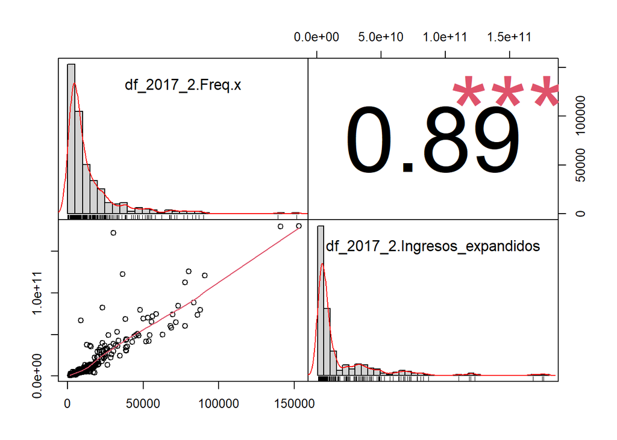

```r
dat1 <- data.frame(df_2017_2$Freq.x, df_2017_2$Ingresos_expandidos)
chart.Correlation(dat1)
```

2 Departamento en edificio

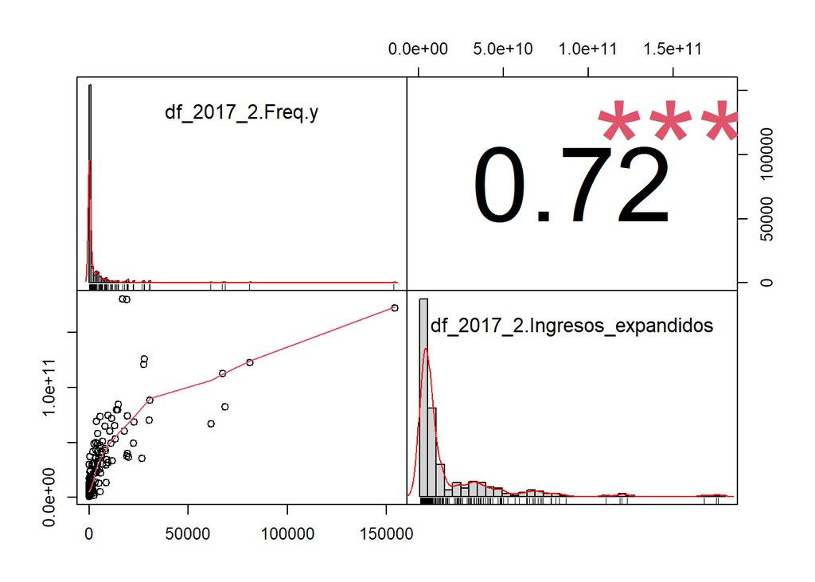

```r
dat1 <- data.frame(df_2017_2$Freq.y, df_2017_2$Ingresos_expandidos)
chart.Correlation(dat1)
```

3 Vivienda tradicional indígena (ruka, pae pae u otras)

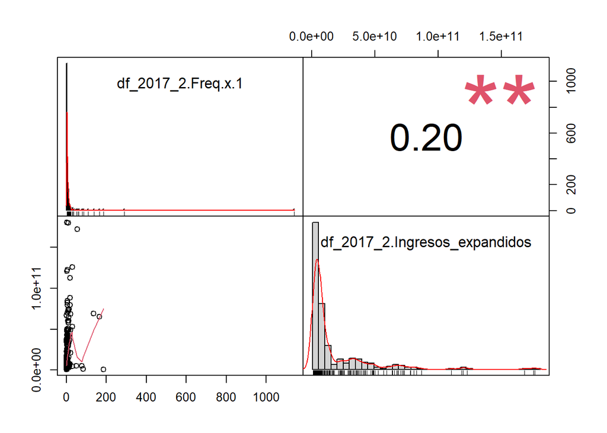

```r
dat1 <- data.frame(df_2017_2$Freq.x.1, df_2017_2$Ingresos_expandidos)
chart.Correlation(dat1)
```

4 Pieza en casa antigua o en conventillo

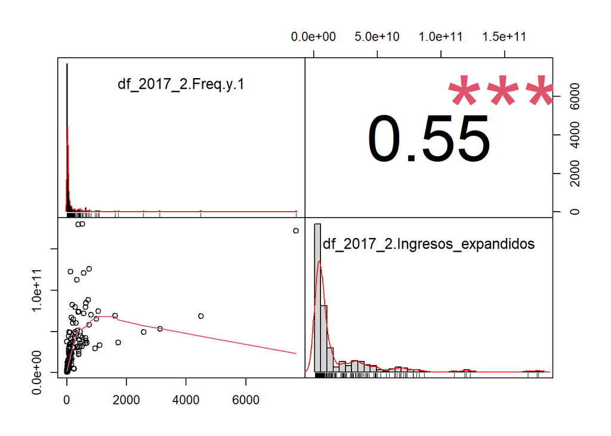

```r
dat1 <- data.frame(df_2017_2$Freq.y.1, df_2017_2$Ingresos_expandidos)
chart.Correlation(dat1)
```

5 Mediagua, mejora, rancho o choza

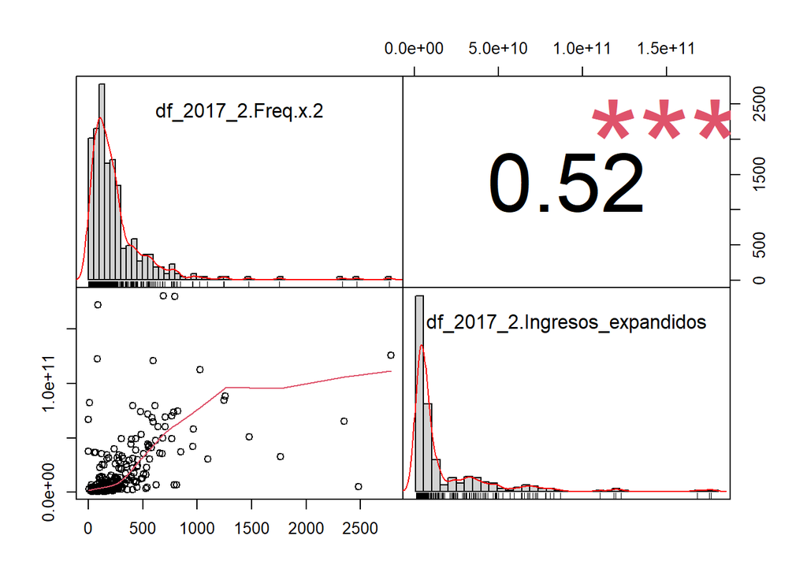

```r
dat1 <- data.frame(df_2017_2$Freq.x.2, df_2017_2$Ingresos_expandidos)
chart.Correlation(dat1)
```

6 Móvil (carpa, casa rodante o similar)

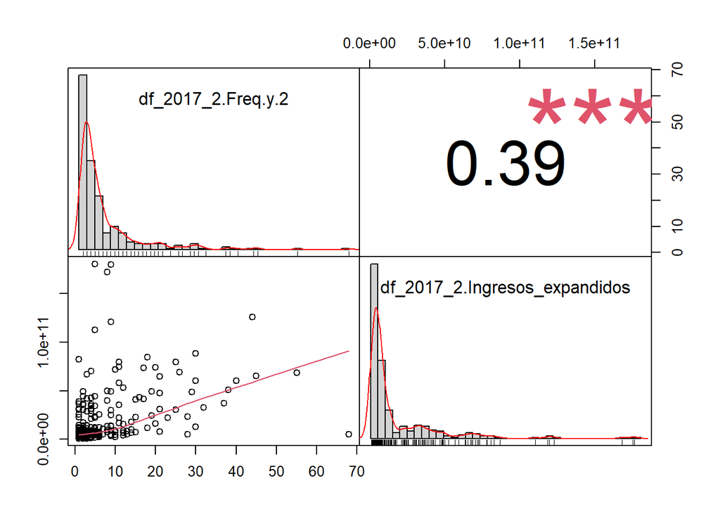

```r
dat1 <- data.frame(df_2017_2$Freq.y.2, df_2017_2$Ingresos_expandidos)
chart.Correlation(dat1)
```

7 Otro tipo de vivienda particular

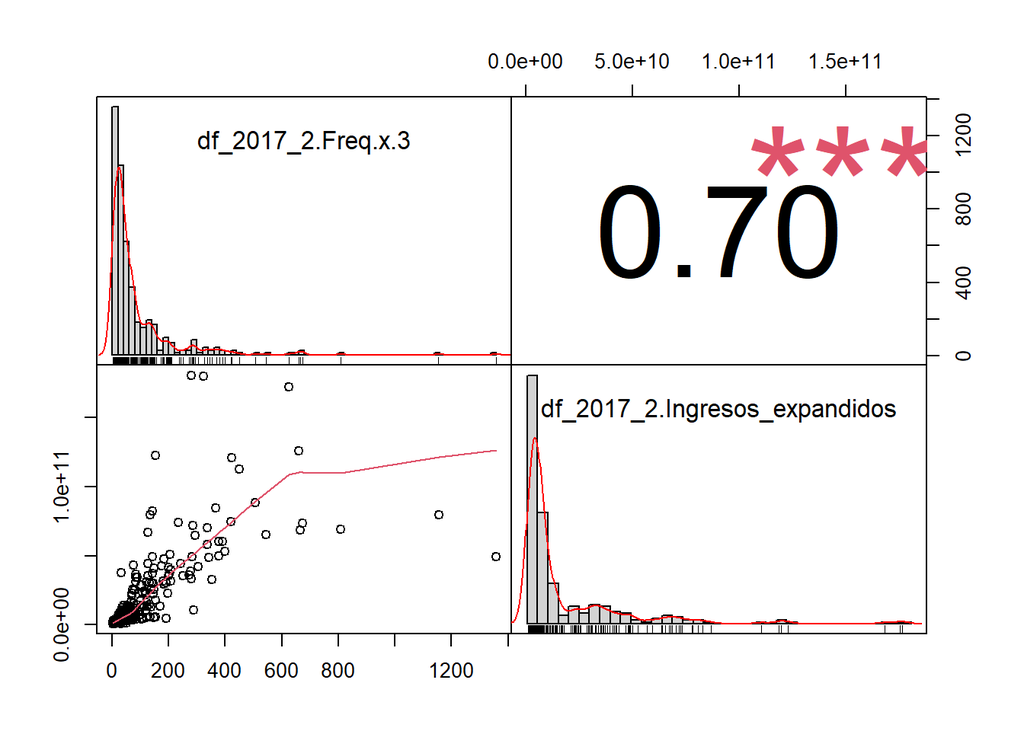

```r
dat1 <- data.frame(df_2017_2$Freq.x.3, df_2017_2$Ingresos_expandidos)
chart.Correlation(dat1)
```

8 Vivienda colectiva

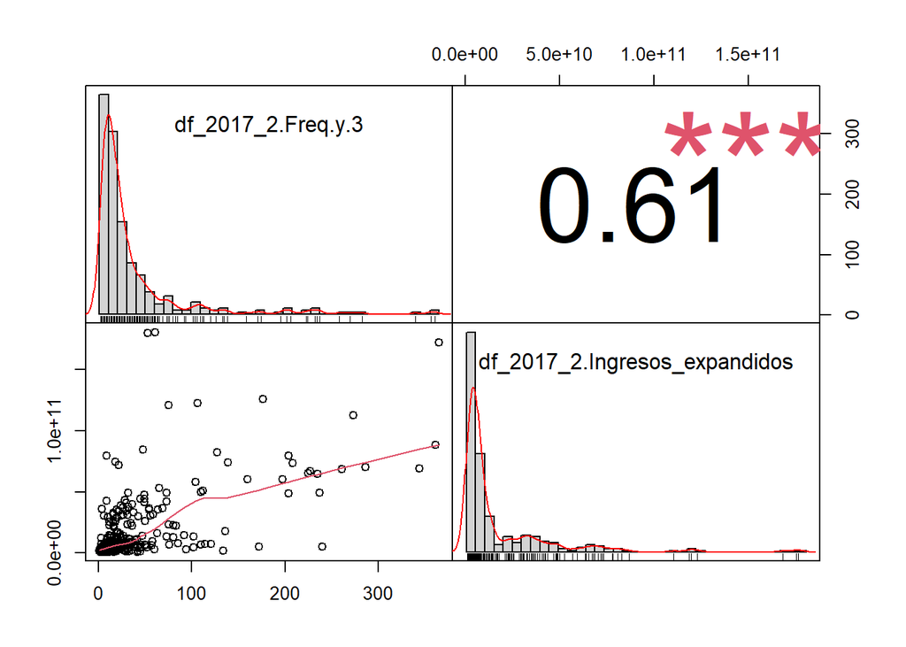

```r
dat1 <- data.frame(df_2017_2$Freq.y.3, df_2017_2$Ingresos_expandidos)
chart.Correlation(dat1)
```

9 Operativo personas en tránsito (no es vivienda)

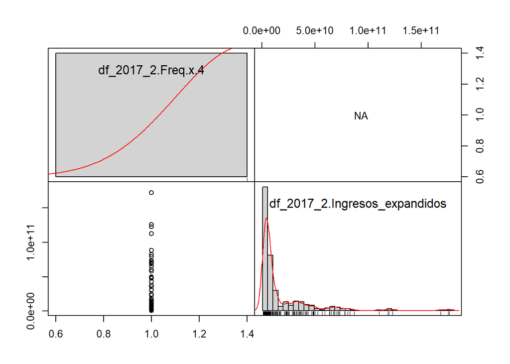

```r
dat1 <- data.frame(df_2017_2$Freq.x.4, df_2017_2$Ingresos_expandidos)
chart.Correlation(dat1)
```

10 Operativo calle (no es vivienda)

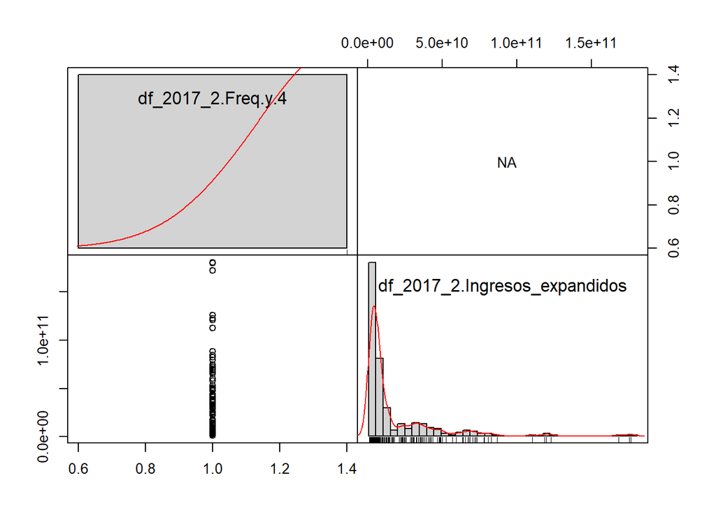

```r
dat1 <- data.frame(df_2017_2$Freq.y.4, df_2017_2$Ingresos_expandidos)
chart.Correlation(dat1)
```